# Heart Failure Prediction Analysis

```python
import pandas as pd
import numpy as np
import plotly.graph_objects as go
import plotly.express as px
from matplotlib import pyplot
import seaborn as sns

import matplotlib.pyplot as plt
%matplotlib inline

from sklearn.preprocessing import StandardScaler, RobustScaler, MinMaxScaler
from sklearn.model_selection import train_test_split, StratifiedShuffleSplit, cross_val_score, GridSearchCV, cross_val_predict
from sklearn.metrics import confusion_matrix, precision_score, recall_score, f1_score, accuracy_score, roc_curve, roc_auc_score

from sklearn.ensemble import RandomForestClassifier
from sklearn.tree import DecisionTreeClassifier
from sklearn.linear_model import LogisticRegression
from sklearn.linear_model import SGDClassifier
from sklearn.neighbors import KNeighborsClassifier
from sklearn.svm import SVC
```

### Read heart csv data

```python
# Load dataset
df = pd.read_csv(r'C:\Users\anjan\Downloads\heart.csv')
df.head()
```

|  | Age | Sex | ChestPainType | RestingBP | Cholesterol | FastingBS | RestingECG | MaxHR | ExerciseAngina | Oldpeak | ST_Slope | HeartDisease |
| --- | --- | --- | --- | --- | --- | --- | --- | --- | --- | --- | --- | --- |
| 0 | 40 | M | ATA | 140 | 289 | 0 | Normal | 172 | N | 0.0 | Up | 0 |
| 1 | 49 | F | NAP | 160 | 180 | 0 | Normal | 156 | N | 1.0 | Flat | 1 |
| 2 | 37 | M | ATA | 130 | 283 | 0 | ST | 98 | N | 0.0 | Up | 0 |
| 3 | 48 | F | ASY | 138 | 214 | 0 | Normal | 108 | Y | 1.5 | Flat | 1 |
| 4 | 54 | M | NAP | 150 | 195 | 0 | Normal | 122 | N | 0.0 | Up | 0 |

### Exploratory Data Analysis

```python
# shape of dataset
df.shape
```

```
(918, 12)
```

```python
# information of the dataset
df.info()
```

```
<class 'pandas.core.frame.DataFrame'>
RangeIndex: 918 entries, 0 to 917
Data columns (total 12 columns):
 #   Column          Non-Null Count  Dtype
---  ------          --------------  -----
 0   Age             918 non-null    int64
 1   Sex             918 non-null    object
 2   ChestPainType   918 non-null    object
 3   RestingBP       918 non-null    int64
 4   Cholesterol     918 non-null    int64
 5   FastingBS       918 non-null    int64
 6   RestingECG      918 non-null    object
 7   MaxHR           918 non-null    int64
 8   ExerciseAngina  918 non-null    object
 9   Oldpeak         918 non-null    float64
 10  ST_Slope        918 non-null    object
 11  HeartDisease    918 non-null    int64
dtypes: float64(1), int64(6), object(5)
memory usage: 86.2+ KB
```

```python
# check for duplicates
duplicates = df.duplicated()
duplicates.value_counts()
```

```
False    918
dtype: int64
```

```python
# check for missing values
df.isna().sum()
```

```
Age               0
Sex               0
ChestPainType     0
RestingBP         0
Cholesterol       0
FastingBS         0
RestingECG        0
MaxHR             0
ExerciseAngina    0
Oldpeak           0
ST_Slope          0
HeartDisease      0
dtype: int64
```

```python
# classify the data to continuous, categorical and binary parameters
continuous_var = ["Age", "RestingBP", "Cholesterol", "MaxHR", "Oldpeak"]
categorical_var = ["ChestPainType", "RestingECG", "ST_Slope"]
binary_var = ["Sex", "FastingBS", "ExerciseAngina"]
```

```python
# EDA of continuous variables
df.describe()
```

|  | Age | RestingBP | Cholesterol | FastingBS | MaxHR | Oldpeak | HeartDisease |
| --- | --- | --- | --- | --- | --- | --- | --- |
| count | 918.000000 | 918.000000 | 918.000000 | 918.000000 | 918.000000 | 918.000000 | 918.000000 |
| mean | 53.510893 | 132.396514 | 198.799564 | 0.233115 | 136.809368 | 0.887364 | 0.553377 |
| std | 9.432617 | 18.514154 | 109.384145 | 0.423046 | 25.460334 | 1.066570 | 0.497414 |
| min | 28.000000 | 0.000000 | 0.000000 | 0.000000 | 60.000000 | -2.600000 | 0.000000 |
| 25% | 47.000000 | 120.000000 | 173.250000 | 0.000000 | 120.000000 | 0.000000 | 0.000000 |
| 50% | 54.000000 | 130.000000 | 223.000000 | 0.000000 | 138.000000 | 0.600000 | 1.000000 |
| 75% | 60.000000 | 140.000000 | 267.000000 | 0.000000 | 156.000000 | 1.500000 | 1.000000 |
| max | 77.000000 | 200.000000 | 603.000000 | 1.000000 | 202.000000 | 6.200000 | 1.000000 |

```
ASY    0.540305
NAP    0.221133
ATA    0.188453
TA     0.050109
Name: ChestPainType, dtype: float64
```

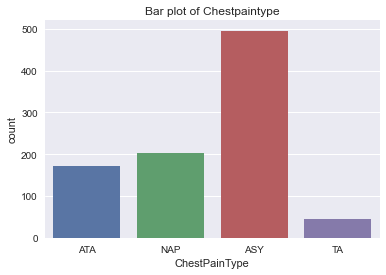

```
Normal    0.601307
LVH       0.204793
ST        0.193900
Name: RestingECG, dtype: float64
```

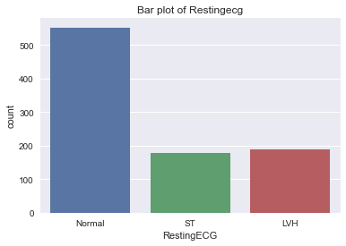

```
Flat    0.501089
Up      0.430283
Down    0.068627
Name: ST_Slope, dtype: float64
```

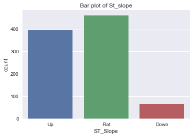

```python
# EDA of categorical variables- frequency table, bar plot
for var in categorical_var:
    freq_table = df[var].value_counts(normalize=True)
    print(freq_table)
    sns.countplot(x=var, data=df)
    plt.title(f'Bar plot of {var.capitalize()}')
    plt.show()
```

```
M    0.78976
F    0.21024
Name: Sex, dtype: float64
```

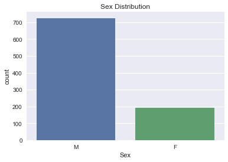

```
0    0.766885
1    0.233115
Name: FastingBS, dtype: float64
```

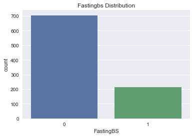

```
N    0.595861
Y    0.404139
Name: ExerciseAngina, dtype: float64
```

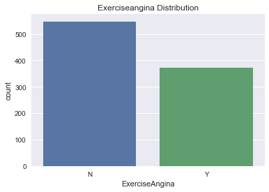

```python
# EDA of binary variables - frequency table, bar plot
for var in binary_var:
    print(df[var].value_counts(normalize=True))
    sns.countplot(x=var, data=df)
    plt.title(f'{var.capitalize()} Distribution')
    plt.show()
```

### Histogram and Density plots

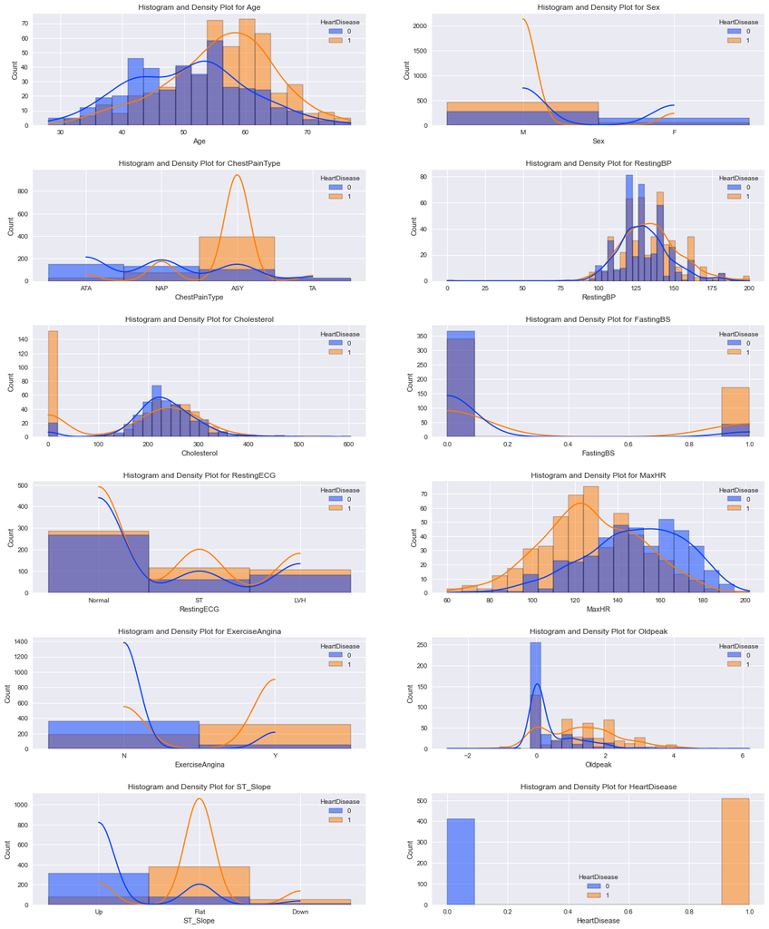

```python
# Plot histograms and density plots for each continuos variable
plt.style.use("seaborn")
plt.figure(figsize=(20, 25))
palette = 'bright'
columns = list(df.columns)

for i, var in enumerate(columns):
    if i<12:
        plt.subplot(6, 2, i+1)
        sns.histplot(data=df, x=var, kde=True, palette=palette, hue='HeartDisease')
        plt.title(f'Histogram and Density Plot for {var}')
        plt.xlabel(var)
plt.subplots_adjust(hspace=0.4)
plt.show()
```

### Boxplots

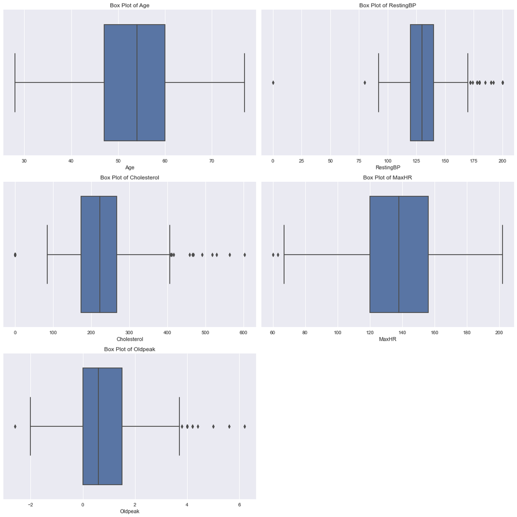

```python
# set the number of columns for the subplots
num_cols = 2

# calculate the number of rows required to display all subplots
num_rows = len(continuous_var) // num_cols + (len(continuous_var) % num_cols > 0)

# create the subplots
fig, axes = plt.subplots(num_rows, num_cols, figsize=(15, 15))

# loop through each continuous variable and create a box plot
for i, var in enumerate(continuous_var):
    row = i // num_cols
    col = i % num_cols
    sns.boxplot(ax=axes[row, col], x=var, data=df)
    axes[row, col].set_title('Box Plot of {}'.format(var))

# remove any extra subplots
for j in range(len(continuous_var), num_rows*num_cols):
    row = j // num_cols
    col = j % num_cols
    fig.delaxes(axes[row, col])
plt.subplots_adjust(hspace=0.5)
plt.subplots_adjust(wspace=1)
plt.tight_layout()
plt.show()
```

### Outliers detection and Treatment

```python
# functions to detect and treat outliers
def detect_outliers(label=None):
    Q1, Q3 = df[label].quantile([0.25, 0.75])
    IQR = Q3 - Q1
    interval = df[label].between(Q1 - 1.5*IQR, Q3 + 1.5*IQR)
    return df[interval], df[~interval]

def assign_mean(out, not_out, label=None):
    for hd in [0, 1]:
        df.loc[out[out["HeartDisease"] == hd].index, label] = not_out[not_out["HeartDisease"] == hd][label].mean()
```

### Cholesterol

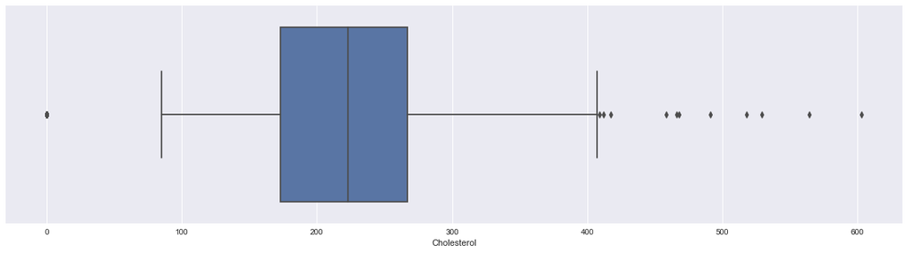

```python
plt.figure(figsize=(20,5))
sns.boxplot(data=df, x="Cholesterol")
```

```python
not_out_ch, out_ch = detect_outliers('Cholesterol')
print(f'Outliers in cholesterol represent the {round((out_ch.shape[0]*100)/df.shape[0], 2)}% of our dataset')
out_ch
```

```
Outliers in cholesterol represent the 19.93% of our dataset
```

|  | Age | Sex | ChestPainType | RestingBP | Cholesterol | FastingBS | RestingECG | MaxHR | ExerciseAngina | Oldpeak | ST_Slope | HeartDisease |
| --- | --- | --- | --- | --- | --- | --- | --- | --- | --- | --- | --- | --- |
| 28 | 53 | F | ATA | 113 | 468 | 0 | Normal | 127 | N | 0.0 | Up | 0 |
| 30 | 53 | M | NAP | 145 | 518 | 0 | Normal | 130 | N | 0.0 | Flat | 1 |
| 69 | 44 | M | ASY | 150 | 412 | 0 | Normal | 170 | N | 0.0 | Up | 0 |
| 76 | 32 | M | ASY | 118 | 529 | 0 | Normal | 130 | N | 0.0 | Flat | 1 |
| 103 | 40 | M | ASY | 120 | 466 | 1 | Normal | 152 | Y | 1.0 | Flat | 1 |
| ... | ... | ... | ... | ... | ... | ... | ... | ... | ... | ... | ... | ... |
| 535 | 56 | M | ASY | 130 | 0 | 0 | LVH | 122 | Y | 1.0 | Flat | 1 |
| 536 | 62 | M | NAP | 133 | 0 | 1 | ST | 119 | Y | 1.2 | Flat | 1 |
| 616 | 67 | F | NAP | 115 | 564 | 0 | LVH | 160 | N | 1.6 | Flat | 0 |
| 667 | 65 | F | NAP | 140 | 417 | 1 | LVH | 157 | N | 0.8 | Up | 0 |
| 796 | 56 | F | ASY | 134 | 409 | 0 | LVH | 150 | Y | 1.9 | Flat | 1 |

183 rows × 12 columns

In cholestrol there are registers with zero values which are human errors, the best solution is to deleted these, while the rest of the register will be assigned the mean cholesterol of the data set.

```
(746, 12)
```

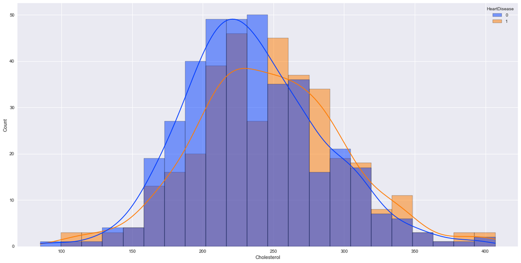

```python
# Cholesterol outliers handling
df = df[df['Cholesterol']!=0]
assign_mean(out_ch[out_ch["Cholesterol"] != 0], not_out_ch, 'Cholesterol')

plt.figure(figsize=(20,10))
sns.histplot(data=df, x='Cholesterol', kde=True, palette='bright', hue='HeartDisease')
df.shape
```

### Resting Blood Pressure

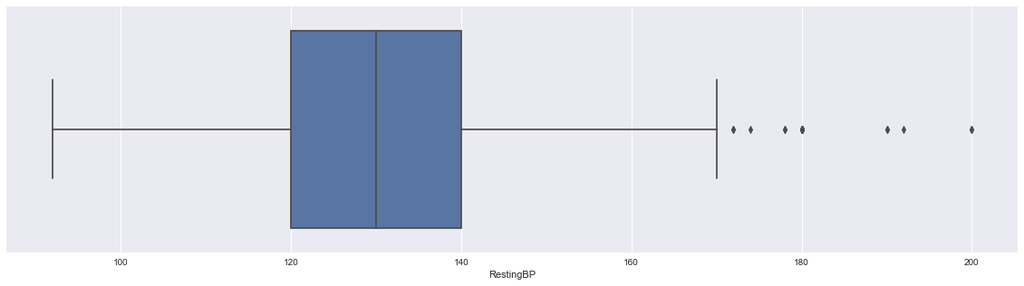

```python
plt.figure(figsize=(20,5))
sns.boxplot(data=df, x="RestingBP")
```

```python
not_out_rbp, out_rbp = detect_outliers('RestingBP')
print(f'Outliers in resting blood pressure represent the {round((out_rbp.shape[0]*100)/df.shape[0], 2)}% of our dataset')
out_rbp
```

```
Outliers in resting blood pressure represent the 2.68% of our dataset
```

|  | Age | Sex | ChestPainType | RestingBP | Cholesterol | FastingBS | RestingECG | MaxHR | ExerciseAngina | Oldpeak | ST_Slope | HeartDisease |
| --- | --- | --- | --- | --- | --- | --- | --- | --- | --- | --- | --- | --- |
| 109 | 39 | M | ATA | 190 | 241.0 | 0 | Normal | 106 | N | 0.0 | Up | 0 |
| 123 | 58 | F | ATA | 180 | 393.0 | 0 | Normal | 110 | Y | 1.0 | Flat | 1 |
| 189 | 53 | M | ASY | 180 | 285.0 | 0 | ST | 120 | Y | 1.5 | Flat | 1 |
| 190 | 46 | M | ASY | 180 | 280.0 | 0 | ST | 120 | N | 0.0 | Up | 0 |
| 241 | 54 | M | ASY | 200 | 198.0 | 0 | Normal | 142 | Y | 2.0 | Flat | 1 |
| 274 | 45 | F | ATA | 180 | 295.0 | 0 | Normal | 180 | N | 0.0 | Up | 0 |
| 275 | 59 | M | NAP | 180 | 213.0 | 0 | Normal | 100 | N | 0.0 | Up | 0 |
| 278 | 57 | F | ASY | 180 | 347.0 | 0 | ST | 126 | Y | 0.8 | Flat | 0 |
| 550 | 55 | M | ASY | 172 | 260.0 | 0 | Normal | 73 | N | 2.0 | Flat | 1 |
| 585 | 57 | M | ATA | 180 | 285.0 | 1 | ST | 120 | N | 0.8 | Flat | 1 |
| 592 | 61 | M | ASY | 190 | 287.0 | 1 | LVH | 150 | Y | 2.0 | Down | 1 |
| 673 | 59 | F | ASY | 174 | 249.0 | 0 | Normal | 143 | Y | 0.0 | Flat | 1 |
| 702 | 59 | M | TA | 178 | 270.0 | 0 | LVH | 145 | N | 4.2 | Down | 0 |
| 725 | 55 | F | ASY | 180 | 327.0 | 0 | ST | 117 | Y | 3.4 | Flat | 1 |
| 732 | 56 | F | ASY | 200 | 288.0 | 1 | LVH | 133 | Y | 4.0 | Down | 1 |
| 759 | 54 | M | ATA | 192 | 283.0 | 0 | LVH | 195 | N | 0.0 | Up | 1 |
| 774 | 66 | F | ASY | 178 | 228.0 | 1 | Normal | 165 | Y | 1.0 | Flat | 1 |
| 780 | 64 | F | ASY | 180 | 325.0 | 0 | Normal | 154 | Y | 0.0 | Up | 0 |
| 855 | 68 | M | NAP | 180 | 274.0 | 1 | LVH | 150 | Y | 1.6 | Flat | 1 |
| 880 | 52 | M | NAP | 172 | 199.0 | 1 | Normal | 162 | N | 0.5 | Up | 0 |

Since this is a small percentage we can delete them.

```python
# Resting BP outliers handling
for i in out_rbp.index:
    df = df.drop(i)
df.shape
```

```
(726, 12)
```

### Oldpeak

```python
not_out_opk, out_opk = detect_outliers('Oldpeak')
print(f'Outliers in Oldpeak represent the {round((out_opk.shape[0]*100)/df.shape[0], 2)}% of our dataset')
out_opk
```

```
Outliers in Oldpeak represent the 1.79% of our dataset
```

|  | Age | Sex | ChestPainType | RestingBP | Cholesterol | FastingBS | RestingECG | MaxHR | ExerciseAngina | Oldpeak | ST_Slope | HeartDisease |
| --- | --- | --- | --- | --- | --- | --- | --- | --- | --- | --- | --- | --- |
| 68 | 52 | M | ASY | 160 | 246.0 | 0 | ST | 82 | Y | 4.0 | Flat | 1 |
| 166 | 50 | M | ASY | 140 | 231.0 | 0 | ST | 140 | Y | 5.0 | Flat | 1 |
| 500 | 65 | M | ASY | 136 | 248.0 | 0 | Normal | 140 | Y | 4.0 | Down | 1 |
| 521 | 61 | M | ASY | 120 | 282.0 | 0 | ST | 135 | Y | 4.0 | Down | 1 |
| 537 | 74 | M | ASY | 150 | 258.0 | 1 | ST | 130 | Y | 4.0 | Down | 1 |
| 559 | 64 | M | ASY | 134 | 273.0 | 0 | Normal | 102 | Y | 4.0 | Down | 1 |
| 624 | 63 | F | ASY | 150 | 407.0 | 0 | LVH | 154 | N | 4.0 | Flat | 1 |
| 771 | 55 | M | ASY | 140 | 217.0 | 0 | Normal | 111 | Y | 5.6 | Down | 1 |
| 775 | 38 | M | TA | 120 | 231.0 | 0 | Normal | 182 | Y | 3.8 | Flat | 1 |
| 791 | 51 | M | ASY | 140 | 298.0 | 0 | Normal | 122 | Y | 4.2 | Flat | 1 |
| 850 | 62 | F | ASY | 160 | 164.0 | 0 | LVH | 145 | N | 6.2 | Down | 1 |
| 900 | 58 | M | ASY | 114 | 318.0 | 0 | ST | 140 | N | 4.4 | Down | 1 |
| 908 | 63 | M | ASY | 140 | 187.0 | 0 | LVH | 144 | Y | 4.0 | Up | 1 |

```python
# Oldpeak outliers handling
for i in out_opk.index:
    df = df.drop(i)
df.shape
```

```
(713, 12)
```

### Pie charts - Heart disease in Females and Males

```python
# Calculate the counts and percentages
counts = [df[(df["Sex"] == 'F') & (df["HeartDisease"] == 0)].count().to_numpy()[0],
          df[(df["Sex"] == 'F') & (df["HeartDisease"] == 1)].count().to_numpy()[0]]
total = sum(counts)
percentages = [count/total*100 for count in counts]

# Define the labels
labels = ["Females without heart disease", "Females with heart disease"]

# Create the pie chart
fig = go.Figure(data=[go.Pie(labels=labels,
                             values=percentages,
                             textinfo='label+percent'
                            )])

# Set the chart title and legend
fig.update_layout(title_text='Probability of heart disease in females', showlegend=True)

# Show the chart
fig.show()
```

[interactive chart not shown]

```python
# Calculate the counts and percentages
counts = [df[(df["Sex"] == 'M') & (df["HeartDisease"] == 0)].count().to_numpy()[0],
          df[(df["Sex"] == 'M') & (df["HeartDisease"] == 1)].count().to_numpy()[0]]
total = sum(counts)
percentages = [count/total*100 for count in counts]

# Define the labels
labels = ["Males without heart disease", "Males with heart disease"]


# Create the pie chart
fig = go.Figure(data=[go.Pie(labels=labels,
                             values=percentages,
                             textinfo='label+percent'
                            )])

# Set the chart title and legend
fig.update_layout(title_text='Probability of heart disease in males', showlegend=True)

# Show the chart
fig.show()
```

[interactive chart not shown]

### Feature Encoding

```python
# Define the mapping dictionaries
sex_map = {'M': 1, 'F': 0}
exercise_map = {'N': 0, 'Y': 1}

# Map the values using the dictionaries
df['Sex'] = df['Sex'].map(sex_map)
df['ExerciseAngina'] = df['ExerciseAngina'].map(exercise_map)
df
```

|  | Age | Sex | ChestPainType | RestingBP | Cholesterol | FastingBS | RestingECG | MaxHR | ExerciseAngina | Oldpeak | ST_Slope | HeartDisease |
| --- | --- | --- | --- | --- | --- | --- | --- | --- | --- | --- | --- | --- |
| 0 | 40 | 1 | ATA | 140 | 289.0 | 0 | Normal | 172 | 0 | 0.0 | Up | 0 |
| 1 | 49 | 0 | NAP | 160 | 180.0 | 0 | Normal | 156 | 0 | 1.0 | Flat | 1 |
| 2 | 37 | 1 | ATA | 130 | 283.0 | 0 | ST | 98 | 0 | 0.0 | Up | 0 |
| 3 | 48 | 0 | ASY | 138 | 214.0 | 0 | Normal | 108 | 1 | 1.5 | Flat | 1 |
| 4 | 54 | 1 | NAP | 150 | 195.0 | 0 | Normal | 122 | 0 | 0.0 | Up | 0 |
| ... | ... | ... | ... | ... | ... | ... | ... | ... | ... | ... | ... | ... |
| 913 | 45 | 1 | TA | 110 | 264.0 | 0 | Normal | 132 | 0 | 1.2 | Flat | 1 |
| 914 | 68 | 1 | ASY | 144 | 193.0 | 1 | Normal | 141 | 0 | 3.4 | Flat | 1 |
| 915 | 57 | 1 | ASY | 130 | 131.0 | 0 | Normal | 115 | 1 | 1.2 | Flat | 1 |
| 916 | 57 | 0 | ATA | 130 | 236.0 | 0 | LVH | 174 | 0 | 0.0 | Flat | 1 |
| 917 | 38 | 1 | NAP | 138 | 175.0 | 0 | Normal | 173 | 0 | 0.0 | Up | 0 |

713 rows × 12 columns

### Data Binning

This code discretizes the continuous features in the original dataframe df into 5 bins and creates a new dataframe df_bin that contains the binned values. This is useful when working with machine learning algorithms that require categorical data, as continuous features can be difficult to work with directly.

```python
# Define the number of bins
bins = 5

# Create a copy of the dataframe
df_bin = df.copy()

# Bin each continuous feature
for feature in continuous_var:
    df_bin[feature] = pd.cut(df[feature], bins=bins, labels=False).astype(int)
df_bin
```

|  | Age | Sex | ChestPainType | RestingBP | Cholesterol | FastingBS | RestingECG | MaxHR | ExerciseAngina | Oldpeak | ST_Slope | HeartDisease |
| --- | --- | --- | --- | --- | --- | --- | --- | --- | --- | --- | --- | --- |
| 0 | 1 | 1 | ATA | 3 | 3 | 0 | Normal | 3 | 0 | 0 | Up | 0 |
| 1 | 2 | 0 | NAP | 4 | 1 | 0 | Normal | 3 | 0 | 1 | Flat | 1 |
| 2 | 0 | 1 | ATA | 2 | 3 | 0 | ST | 1 | 0 | 0 | Up | 0 |
| 3 | 2 | 0 | ASY | 2 | 2 | 0 | Normal | 1 | 1 | 2 | Flat | 1 |
| 4 | 2 | 1 | NAP | 3 | 1 | 0 | Normal | 1 | 0 | 0 | Up | 0 |
| ... | ... | ... | ... | ... | ... | ... | ... | ... | ... | ... | ... | ... |
| 913 | 1 | 1 | TA | 1 | 2 | 0 | Normal | 2 | 0 | 1 | Flat | 1 |
| 914 | 4 | 1 | ASY | 3 | 1 | 1 | Normal | 2 | 0 | 4 | Flat | 1 |
| 915 | 2 | 1 | ASY | 2 | 0 | 0 | Normal | 1 | 1 | 1 | Flat | 1 |
| 916 | 2 | 0 | ATA | 2 | 2 | 0 | LVH | 3 | 0 | 0 | Flat | 1 |
| 917 | 1 | 1 | NAP | 2 | 1 | 0 | Normal | 3 | 0 | 0 | Up | 0 |

713 rows × 12 columns

### One-hot Encode

```python
# Create a list of features to one-hot encode
features_to_encode = categorical_var + continuous_var

# One-hot encode the selected features
df_dumm = pd.get_dummies(df_bin, columns=features_to_encode)
df_dumm
```

|  | Sex | FastingBS | ExerciseAngina | HeartDisease | ChestPainType_ASY | ChestPainType_ATA | ChestPainType_NAP | ChestPainType_TA | RestingECG_LVH | RestingECG_Normal | ... | MaxHR_0 | MaxHR_1 | MaxHR_2 | MaxHR_3 | MaxHR_4 | Oldpeak_0 | Oldpeak_1 | Oldpeak_2 | Oldpeak_3 | Oldpeak_4 |
| --- | --- | --- | --- | --- | --- | --- | --- | --- | --- | --- | --- | --- | --- | --- | --- | --- | --- | --- | --- | --- | --- |
| 0 | 1 | 0 | 0 | 0 | 0 | 1 | 0 | 0 | 0 | 1 | ... | 0 | 0 | 0 | 1 | 0 | 1 | 0 | 0 | 0 | 0 |
| 1 | 0 | 0 | 0 | 1 | 0 | 0 | 1 | 0 | 0 | 1 | ... | 0 | 0 | 0 | 1 | 0 | 0 | 1 | 0 | 0 | 0 |
| 2 | 1 | 0 | 0 | 0 | 0 | 1 | 0 | 0 | 0 | 0 | ... | 0 | 1 | 0 | 0 | 0 | 1 | 0 | 0 | 0 | 0 |
| 3 | 0 | 0 | 1 | 1 | 1 | 0 | 0 | 0 | 0 | 1 | ... | 0 | 1 | 0 | 0 | 0 | 0 | 0 | 1 | 0 | 0 |
| 4 | 1 | 0 | 0 | 0 | 0 | 0 | 1 | 0 | 0 | 1 | ... | 0 | 1 | 0 | 0 | 0 | 1 | 0 | 0 | 0 | 0 |
| ... | ... | ... | ... | ... | ... | ... | ... | ... | ... | ... | ... | ... | ... | ... | ... | ... | ... | ... | ... | ... | ... |
| 913 | 1 | 0 | 0 | 1 | 0 | 0 | 0 | 1 | 0 | 1 | ... | 0 | 0 | 1 | 0 | 0 | 0 | 1 | 0 | 0 | 0 |
| 914 | 1 | 1 | 0 | 1 | 1 | 0 | 0 | 0 | 0 | 1 | ... | 0 | 0 | 1 | 0 | 0 | 0 | 0 | 0 | 0 | 1 |
| 915 | 1 | 0 | 1 | 1 | 1 | 0 | 0 | 0 | 0 | 1 | ... | 0 | 1 | 0 | 0 | 0 | 0 | 1 | 0 | 0 | 0 |
| 916 | 0 | 0 | 0 | 1 | 0 | 1 | 0 | 0 | 1 | 0 | ... | 0 | 0 | 0 | 1 | 0 | 1 | 0 | 0 | 0 | 0 |
| 917 | 1 | 0 | 0 | 0 | 0 | 0 | 1 | 0 | 0 | 1 | ... | 0 | 0 | 0 | 1 | 0 | 1 | 0 | 0 | 0 | 0 |

713 rows × 39 columns

### Correlation computation

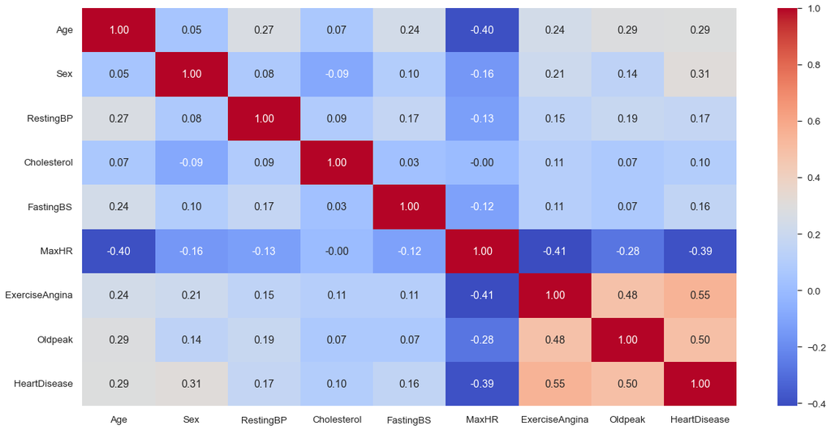

```python
# Compute the correlation matrix
corr = df.corr()

# Set the figure size and font scale
sns.set(rc={'figure.figsize':(20,10)}, font_scale=1.2)

# Create a heatmap of the correlation matrix
sns.heatmap(corr, cmap='coolwarm', annot=True, fmt='.2f')
```

```python
# Compute the correlation coefficients and sort them in descending order
df_corr = df_dumm.corr()['HeartDisease'].sort_values(ascending=False)
df_corr

# Top features are: ST_Slope_Flat, ExerciseAngina, ChestPainType_ASY, Sex
```

```
HeartDisease         1.000000
ST_Slope_Flat        0.606063
ExerciseAngina       0.549594
ChestPainType_ASY    0.522760
Sex                  0.307948
Oldpeak_2            0.286330
MaxHR_1              0.248172
Age_3                0.231030
Oldpeak_4            0.205033
Oldpeak_3            0.178541
FastingBS            0.160581
Oldpeak_1            0.123364
RestingBP_4          0.117451
MaxHR_0              0.103976
ST_Slope_Down        0.102803
RestingECG_ST        0.088794
Cholesterol_3        0.088486
Age_4                0.085272
RestingBP_3          0.081389
MaxHR_2              0.081099
RestingECG_LVH       0.066322
Cholesterol_4        0.045321
Cholesterol_0        0.011541
RestingBP_2         -0.011129
Cholesterol_2       -0.015179
Age_2               -0.038042
ChestPainType_TA    -0.050771
RestingBP_0         -0.072372
Cholesterol_1       -0.081825
RestingBP_1         -0.109401
RestingECG_Normal   -0.124279
Age_0               -0.137516
Age_1               -0.165213
MaxHR_4             -0.206907
ChestPainType_NAP   -0.213355
MaxHR_3             -0.228525
ChestPainType_ATA   -0.381650
Oldpeak_0           -0.486656
ST_Slope_Up         -0.649144
Name: HeartDisease, dtype: float64
```

### Divide data into training and testset

```python
# Make a copy of the one-hot encoded dataframe
df_clean = df_dumm.copy()

# Separate the features and target variable
X = df_clean.drop("HeartDisease", axis=1)
y = df_clean["HeartDisease"]

# Split the data into training and testing sets
train_size = 0.8
X_train, X_test, y_train, y_test = train_test_split(X, y, train_size=train_size, stratify=y, random_state=42)
X_train.shape, X_test.shape
```

```
((570, 38), (143, 38))
```

### Plot ROC curve and Compute Performance Metrics

```python
scoring_metric = 'recall'
cv = 15
n_features = len(X_train.columns)

def plot_roc_curve(fpr, tpr, label=None):
    plt.plot(fpr, tpr, linewidth=2, label=label)
    plt.plot([0, 1], [0, 1], 'k--')
    plt.axis([0, 1, 0, 1])
    plt.xlabel("False Positive Rate")
    plt.ylabel("True Positive Rate")

def print_scores(y_true, y_pred):
    ac = accuracy_score(y_true, y_pred)
    pr = precision_score(y_true, y_pred)
    rc = recall_score(y_true, y_pred)
    f1 = f1_score(y_true, y_pred, average='weighted')
    print(f"Accuracy: {round(ac,4)}")
    print(f"Precision: {round(pr,4)}")
    print(f"Recall: {round(rc, 4)}")
    print(f"F1-score: {round(f1, 4)}")
    return {'accuracy': ac, 'precision': pr, 'recall': rc, 'f1-score': f1}
```

### 1. Logistic regression model

```python
# Create a logistic regression model with a higher maximum number of iterations
lr_model = LogisticRegression(max_iter=1000)

# Fit the model to the training data
lr_model.fit(X_train, y_train)

# Predict the target variable for the testing data
y_test_pred = lr_model.predict(X_test)

# Calculate the accuracy of the model's predictions
accuracy = lr_model.score(X_test, y_test)

print(" Logistic Regression Model Accuracy:", round(accuracy,4))
```

```
 Logistic Regression Model Accuracy: 0.8881
```

### Feature score calculation

```python
# get importance
importance = lr_model.coef_[0]
# summarize feature importance
for i,v in enumerate(importance):
 print(f'Feature: {X_train.columns[i]}, {i}, Score: {v}')

# top features: Sex, ChestPainType_ASY, ST_Slope_Flat, ST_Slope_Up
```

```
Feature: Sex, 0, Score: 1.627214682431036
Feature: FastingBS, 1, Score: 0.6430199596461487
Feature: ExerciseAngina, 2, Score: 0.7540191417920546
Feature: ChestPainType_ASY, 3, Score: 1.0800278222666506
Feature: ChestPainType_ATA, 4, Score: -0.6481412995716664
Feature: ChestPainType_NAP, 5, Score: -0.4534948764826624
Feature: ChestPainType_TA, 6, Score: 0.021010692188844177
Feature: RestingECG_LVH, 7, Score: 0.08974543925441311
Feature: RestingECG_Normal, 8, Score: -0.0851698655368861
Feature: RestingECG_ST, 9, Score: -0.005173235316358805
Feature: ST_Slope_Down, 10, Score: 0.15758632664800679
Feature: ST_Slope_Flat, 11, Score: 1.0737037654158794
Feature: ST_Slope_Up, 12, Score: -1.231887753662721
Feature: Age_0, 13, Score: 0.06835670370617089
Feature: Age_1, 14, Score: -0.34258625188959824
Feature: Age_2, 15, Score: -0.15166842977515854
Feature: Age_3, 16, Score: 0.32189894310333256
Feature: Age_4, 17, Score: 0.10340137325641888
Feature: RestingBP_0, 18, Score: -0.25378701487932404
Feature: RestingBP_1, 19, Score: -0.15673929484012422
Feature: RestingBP_2, 20, Score: -0.07838883372591698
Feature: RestingBP_3, 21, Score: 0.11711549331414578
Feature: RestingBP_4, 22, Score: 0.3712019885323867
Feature: Cholesterol_0, 23, Score: -0.14667992276708505
Feature: Cholesterol_1, 24, Score: -0.03600336118426933
Feature: Cholesterol_2, 25, Score: 0.003919245384065661
Feature: Cholesterol_3, 26, Score: 0.5298862676946405
Feature: Cholesterol_4, 27, Score: -0.3517198907261861
Feature: MaxHR_0, 28, Score: 0.34716112378496544
Feature: MaxHR_1, 29, Score: 0.0687473955495727
Feature: MaxHR_2, 30, Score: 0.02662096638177049
Feature: MaxHR_3, 31, Score: 0.416362717810434
Feature: MaxHR_4, 32, Score: -0.8594898651255769
Feature: Oldpeak_0, 33, Score: -0.7533115515612949
Feature: Oldpeak_1, 34, Score: -0.6650459933131286
Feature: Oldpeak_2, 35, Score: 0.001770612862631116
Feature: Oldpeak_3, 36, Score: 0.485915093723606
Feature: Oldpeak_4, 37, Score: 0.9300741766893543
```

### Model performance on test data

[figure not shown]

```python
# Display the confusion matrix using a heatmap
confusion_mx = confusion_matrix(y_test, y_test_pred)
sns.heatmap(confusion_mx, annot=True, fmt='')
```

[figure not shown]

[output not shown]

```python
# Plot ROC curve and compute AUC score
fpr_knn, tpr_knn, thresholds_knn = roc_curve(y_test, y_test_pred)
plot_roc_curve(fpr_knn, tpr_knn, "Logistic Regression")
plt.show()
auc_score = roc_auc_score(y_test, y_test_pred)
print(f'AUC score: {round(auc_score,4)}')
```

```python
# Display performance metric score for Random Forest classifier
lr_metrics = print_scores(y_test, y_test_pred)
```

[output not shown]

### 2. Decision Tree Classifier Model

```python
# Create a Decision Tree Classifier model with maximum depth of 3 and random state of 42
dt_model = DecisionTreeClassifier(max_depth=3, random_state=42)

# Train the Decision Tree Classifier model using the training data
dt_model.fit(X_train, y_train)

# Make predictions on the test data
y_test_pred = dt_model.predict(X_test)

# Calculate the accuracy score of the Decision Tree Classifier model
accuracy = accuracy_score(y_test, y_test_pred)

print("Decision Tree Classifier accuracy:", round(accuracy,4))
```

```
Decision Tree Classifier accuracy: 0.8951
```

### Feature score calculation

```
Feature: Sex, Score: 0.08753196882606744
Feature: FastingBS, Score: 0.0
Feature: ExerciseAngina, Score: 0.07228864338592687
Feature: ChestPainType_ASY, Score: 0.062329226161278554
Feature: ChestPainType_ATA, Score: 0.0
Feature: ChestPainType_NAP, Score: 0.0
Feature: ChestPainType_TA, Score: 0.0
Feature: RestingECG_LVH, Score: 0.0
Feature: RestingECG_Normal, Score: 0.0
Feature: RestingECG_ST, Score: 0.0
Feature: ST_Slope_Down, Score: 0.0
Feature: ST_Slope_Flat, Score: 0.0
Feature: ST_Slope_Up, Score: 0.7225649000510793
Feature: Age_0, Score: 0.0
Feature: Age_1, Score: 0.0
Feature: Age_2, Score: 0.0
Feature: Age_3, Score: 0.0
Feature: Age_4, Score: 0.0
Feature: RestingBP_0, Score: 0.0
Feature: RestingBP_1, Score: 0.0
Feature: RestingBP_2, Score: 0.0
Feature: RestingBP_3, Score: 0.0
Feature: RestingBP_4, Score: 0.0
Feature: Cholesterol_0, Score: 0.0
Feature: Cholesterol_1, Score: 0.0
Feature: Cholesterol_2, Score: 0.0
Feature: Cholesterol_3, Score: 0.0
Feature: Cholesterol_4, Score: 0.0
Feature: MaxHR_0, Score: 0.0
Feature: MaxHR_1, Score: 0.0
Feature: MaxHR_2, Score: 0.0
Feature: MaxHR_3, Score: 0.0
Feature: MaxHR_4, Score: 0.04400767106241912
Feature: Oldpeak_0, Score: 0.0
Feature: Oldpeak_1, Score: 0.0
Feature: Oldpeak_2, Score: 0.0
Feature: Oldpeak_3, Score: 0.0
Feature: Oldpeak_4, Score: 0.011277590513228802
```

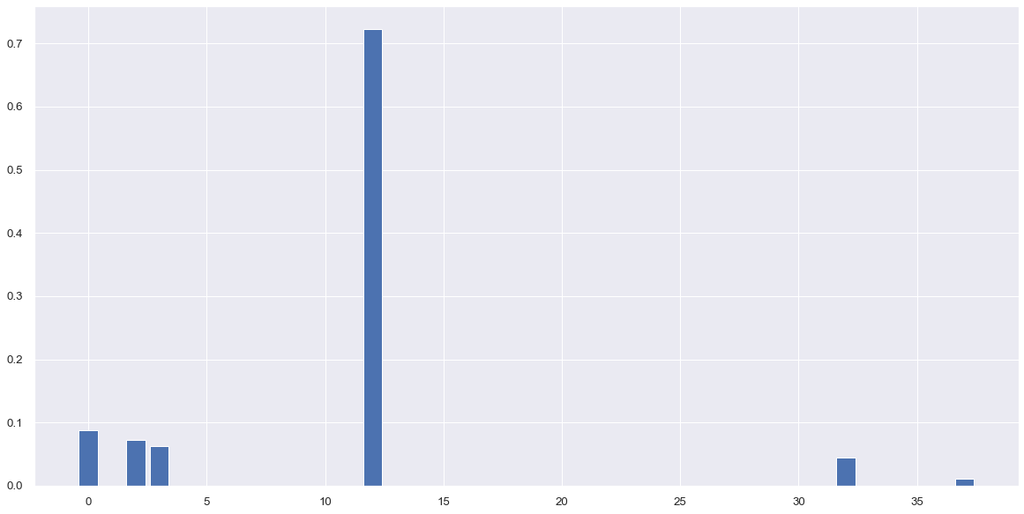

```python
# get importance
importance = dt_model.feature_importances_
# summarize feature importance
for i,v in enumerate(importance):
 print(f'Feature: {X_train.columns[i]}, Score: {v}')
# plot feature importance
pyplot.bar([x for x in range(len(importance))], importance)
pyplot.show()

# Top features: ST_Slope_Up, Sex, ExerciseAngina, ChestPainType_ASY
```

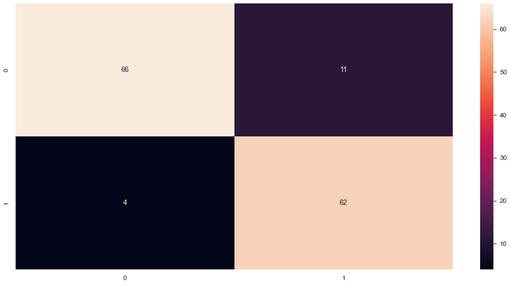

```python
# Display the confusion matrix using a heatmap
confusion_mx = confusion_matrix(y_test, y_test_pred)
sns.heatmap(confusion_mx, annot=True, fmt='')
```

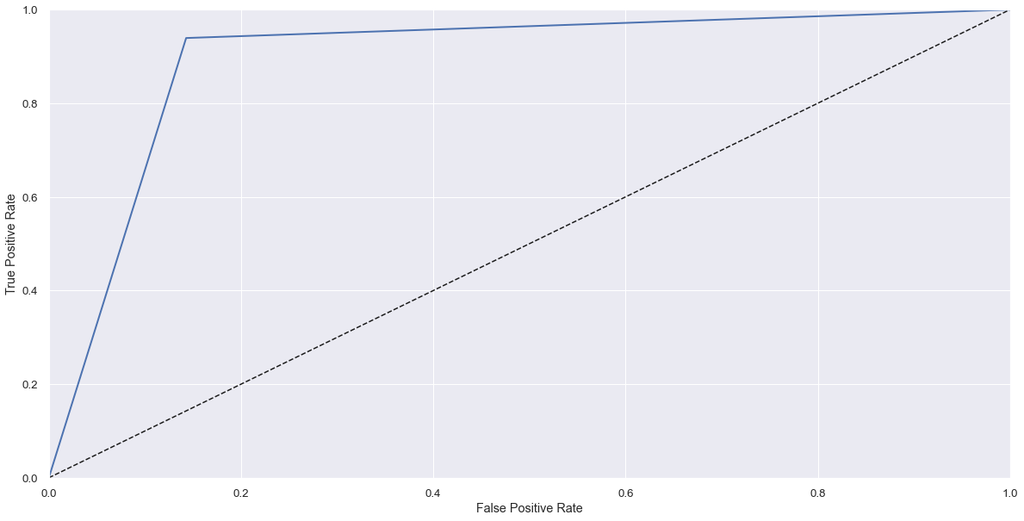

[output not shown]

```python
# Plot ROC curve and compute AUC score
fpr_knn, tpr_knn, thresholds_knn = roc_curve(y_test, y_test_pred)
plot_roc_curve(fpr_knn, tpr_knn, "Logistic Regression")
plt.show()
auc_score = roc_auc_score(y_test, y_pred)
print(f'AUC score: {round(auc_score,4)}')
```

```python
# Display performance metric score for Random Forest classifier
dt_metrics = print_scores(y_test, y_test_pred)
```

```
Accuracy: 0.8951
Precision: 0.8493
Recall: 0.9394
F1-score: 0.8952
```

### 3. K-Nearest Neighbors Classifier

Hyperparameter tuning for the K-Nearest Neighbors (KNN) classifier using GridSearchCV. It searches for the best combination of hyperparameters from a given range of values for 'n_neighbors', 'weights', and 'p'. It then trains the KNN classifier with the best hyperparameters on the training data and evaluates its performance using cross-validation.

```python
param_grid = [{ 'n_neighbors':np.arange(5, 21), 'weights':['uniform', 'distance'],
    'p':[1, 2],
}]

knn_clf = KNeighborsClassifier()
grid_search = GridSearchCV(knn_clf, param_grid, cv=cv, scoring=scoring_metric)
grid_search.fit(X_train, y_train)

best_knn_clf = grid_search.best_estimator_
best_params = grid_search.best_params_
```

### Feature score calculation

```python
from sklearn.linear_model import LogisticRegression

# Extract best hyperparameters from grid search
best_n_neighbors = best_params['n_neighbors']
best_weights = best_params['weights']
best_p = best_params['p']

# Initialize k-NN classifier with best hyperparameters
knn_clf = KNeighborsClassifier(n_neighbors=best_n_neighbors, weights=best_weights, p=best_p)

# Fit k-NN classifier on training data
knn_clf.fit(X_train, y_train)

# Get distances and indices of nearest neighbors for each sample in training data
distances, indices = knn_clf.kneighbors(X_train)

# Compute mean distance to nearest neighbors for each sample
mean_distance = distances.mean(axis=1)

# Add new features to training data
X_train_new = np.c_[X_train, mean_distance]

# Train a logistic regression classifier on the new features
lr_clf = LogisticRegression(random_state=42)
lr_clf.fit(X_train_new, y_train)

# Extract feature coefficients and sort them in descending order
coef = lr_clf.coef_[0]
print(coef)
feature_names = ['feature'+str(i+1) for i in range(X_train_new.shape[1])]

sorted_features = sorted(zip(feature_names, coef), key=lambda x: abs(x[1]), reverse=True)

print("Feature ranking:")
for f in range(len(sorted_features)):
    print("%d. %s (%f)" % (f + 1, sorted_features[f][0], sorted_features[f][1]))
## Top features: Sex,  ST_Slope_Up, ChestPainType_ASY, ST_Slope_Flat
```

```
[ 1.68114596  0.57256392  0.74308807  1.14492608 -0.60292935 -0.45576972
 -0.08659932  0.05078244 -0.01247164 -0.03868311  0.07524041  1.10496524
 -1.18057796  0.02472563 -0.30381651 -0.09669514  0.33175229  0.04366142
 -0.33385373 -0.13040056 -0.02739699  0.13627857  0.35500041 -0.18265328
 -0.02239494  0.06428398  0.54034629 -0.39995436  0.29558189  0.09020541
  0.05902584  0.47110463 -0.91629007 -0.66808169 -0.66985909  0.01156391
  0.46989212  0.85611246  0.15030953]
Feature ranking:
1. feature1 (1.681146)
2. feature13 (-1.180578)
3. feature4 (1.144926)
4. feature12 (1.104965)
5. feature33 (-0.916290)
6. feature38 (0.856112)
7. feature3 (0.743088)
8. feature35 (-0.669859)
9. feature34 (-0.668082)
10. feature5 (-0.602929)
11. feature2 (0.572564)
12. feature27 (0.540346)
13. feature32 (0.471105)
14. feature37 (0.469892)
15. feature6 (-0.455770)
16. feature28 (-0.399954)
17. feature23 (0.355000)
18. feature19 (-0.333854)
19. feature17 (0.331752)
20. feature15 (-0.303817)
21. feature29 (0.295582)
22. feature24 (-0.182653)
23. feature39 (0.150310)
24. feature22 (0.136279)
25. feature20 (-0.130401)
26. feature16 (-0.096695)
27. feature30 (0.090205)
28. feature7 (-0.086599)
29. feature11 (0.075240)
30. feature26 (0.064284)
31. feature31 (0.059026)
32. feature8 (0.050782)
33. feature18 (0.043661)
34. feature10 (-0.038683)
35. feature21 (-0.027397)
36. feature14 (0.024726)
37. feature25 (-0.022395)
38. feature9 (-0.012472)
39. feature36 (0.011564)
```

### Model performance on training data

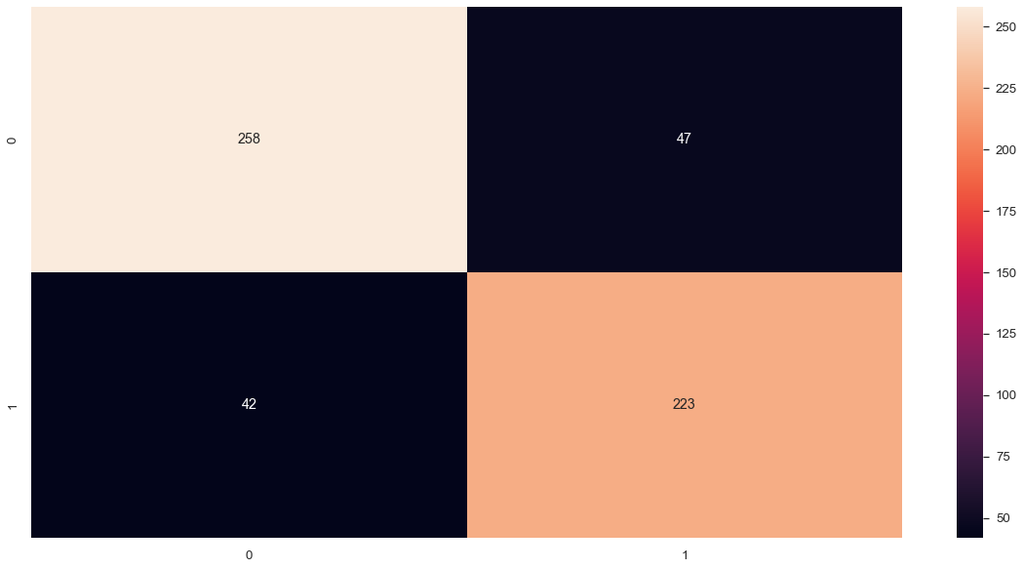

```python
# Display the confusion matrix using a heatmap
y_train_pred = cross_val_predict(best_knn_clf, X_train, y_train, cv=cv)
confusion_mx = confusion_matrix(y_train, y_train_pred)
sns.heatmap(confusion_mx, annot=True, fmt='')
```

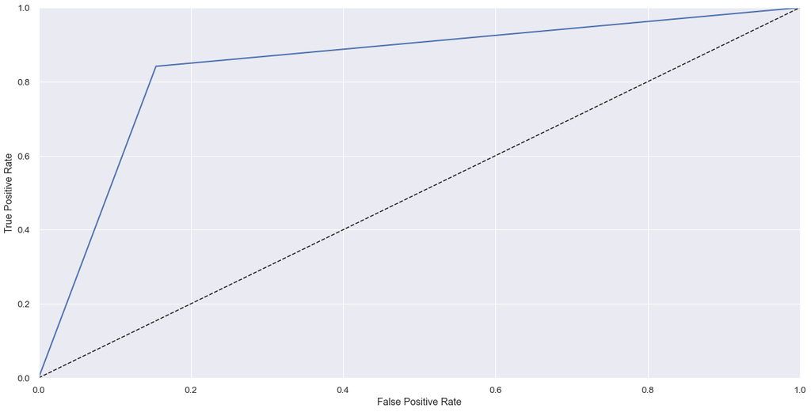

```
AUC: 0.8437
```

```python
# Compute the FPR, TPR, and thresholds for the K-Nearest Neighbors classifier's predictions on the training set
fpr, tpr, thresholds = roc_curve(y_train, y_train_pred)

# Plot the ROC curve for the K-Nearest Neighbors classifier
plot_roc_curve(fpr, tpr, "K-Nearest Neighbors")

# Display the plot
plt.show()
score = roc_auc_score(y_train, y_train_pred)
print(f'AUC: {round(score, 4)}')
```

### Model performance on Test data

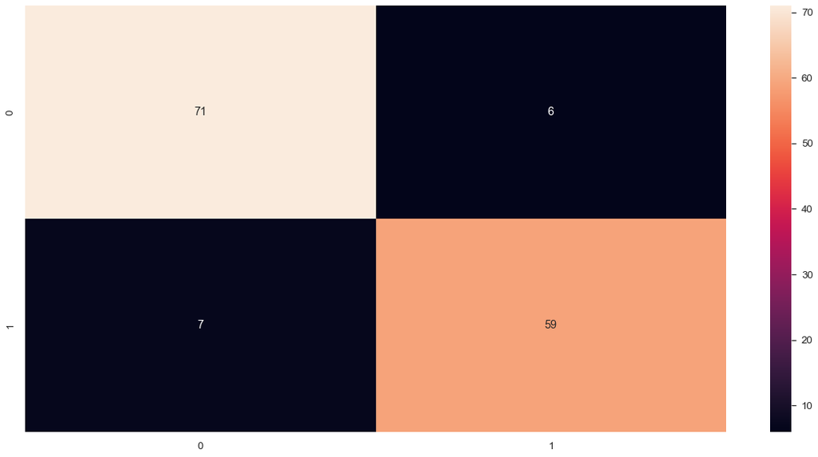

```python
# Perform cross-validation prediction on the test data using the best KNN classifier
y_test_pred = cross_val_predict(best_knn_clf, X_test, y_test, cv=cv)

# Compute the confusion matrix
confusion_mx = confusion_matrix(y_test, y_test_pred)

# Display the confusion matrix using a heatmap
sns.heatmap(confusion_mx, annot=True, fmt='')
```

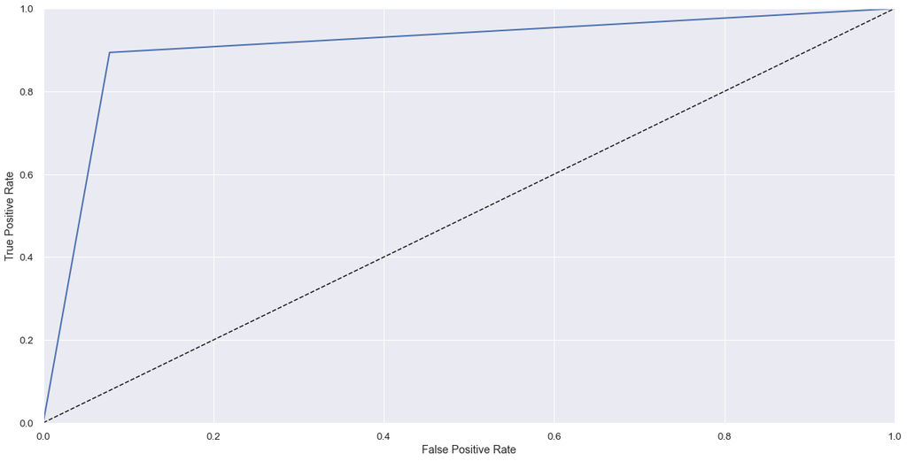

```
AUC score: 0.908
```

```python
# Plot ROC curve and compute AUC score
fpr_knn, tpr_knn, thresholds_knn = roc_curve(y_test, y_test_pred)
plot_roc_curve(fpr_knn, tpr_knn, "K-Nearest Neighbors")
plt.show()
auc_score = roc_auc_score(y_test, y_test_pred)
print(f'AUC score: {round(auc_score,4)}')
```

```python
# Display performance metric score for KNN classifier
knn_metrics = print_scores(y_test, y_test_pred)
```

```
Accuracy: 0.9091
Precision: 0.9077
Recall: 0.8939
F1-score: 0.909
```

### 4. Support Vector Machine Classifier

Perform a grid search to find the best hyperparameters for a support vector machine (SVM) classifier using cross-validation. The optimized hyperparameters are then used to train the SVM classifier on the training data, make predictions on the training data, and generate a confusion matrix visualization.

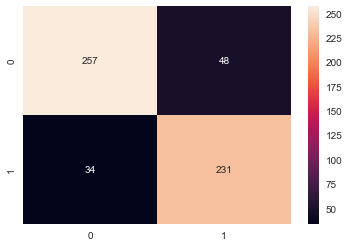

```python
# Define the hyperparameter grid to search
param_grid = [{
    "C": np.linspace(1, 1.5, 10),
    "kernel": ['linear', 'poly', 'rbf', 'sigmoid'],
    "gamma": ['scale', 'auto']
}]

# Initialize and fit the grid search object
svm_clf = SVC()
grid_search = GridSearchCV(svm_clf, param_grid, scoring=scoring_metric, cv=cv)
grid_search.fit(X_train, y_train)

# Retrieve the best estimator and best hyperparameters found
best_svm_clf = grid_search.best_estimator_
best_params = grid_search.best_params_

# Use the best estimator to make predictions on the training data
y_train_pred = cross_val_predict(best_svm_clf, X_train, y_train, cv=cv)

# Generate and display the confusion matrix
conf_mx = confusion_matrix(y_train, y_train_pred)
sns.heatmap(conf_mx, annot=True, fmt='')
```

```python
if best_svm_clf.kernel == 'linear':
    # Get the feature importances (coefficients) from the best estimator
    coef = best_svm_clf.coef_
    # Get the names of the features from the X_train dataframe
    feature_names = X_train.columns
    # Create a dictionary to store the feature names and importances
    feature_importances = dict(zip(feature_names, coef[0]))
    # Sort the dictionary by importance (absolute value)
    sorted_importances = sorted(feature_importances.items(), key=lambda x: abs(x[1]), reverse=True)
    # Print the top features
    top_features = sorted_importances[:10]
    print('Top 10 features:')
    for feature in top_features:
        print(feature[0], ':', feature[1])
else:
    print('Best estimator does not have a linear kernel, cannot calculate feature importances.')
```

```
Best estimator does not have a linear kernel, cannot calculate feature importances.
```

### Model performance on train data

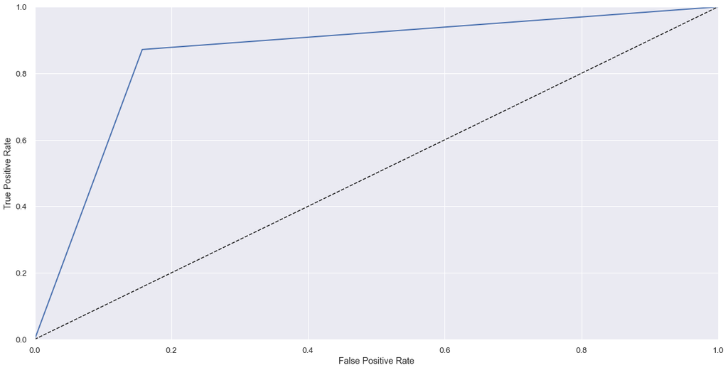

```
AUC: 0.8572
```

```python
# Plot ROC curve and compute AUC score on train data
fpr_svm, tpr_svm, thresholds_svm = roc_curve(y_train, y_train_pred)
plot_roc_curve(fpr_svm, tpr_svm, "SVC")
plt.show()

auc_score = roc_auc_score(y_train, y_train_pred)
print(f'AUC: {round(auc_score, 4)}')
```

### Model performance on test data

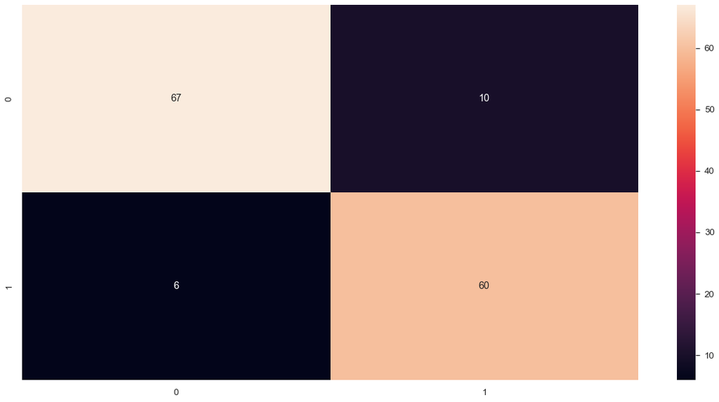

```python
# Generate and display the confusion matrix
y_test_pred = cross_val_predict(best_svm_clf, X_test, y_test, cv=cv)
confusion_mx = confusion_matrix(y_test, y_test_pred)
sns.heatmap(confusion_mx, annot=True, fmt='')
```

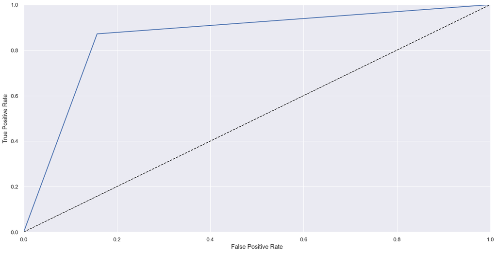

```
AUC score: 0.8572
```

```python
# Plot ROC curve and compute AUC score
fpr_svm, tpr_svm, thresholds_svm = roc_curve(y_train, y_train_pred)
plot_roc_curve(fpr_svm, tpr_svm, "SVC")
plt.show()
auc = roc_auc_score(y_train, y_train_pred)
print(f'AUC score: {round(auc, 4)}')
```

### Model performance on Test data

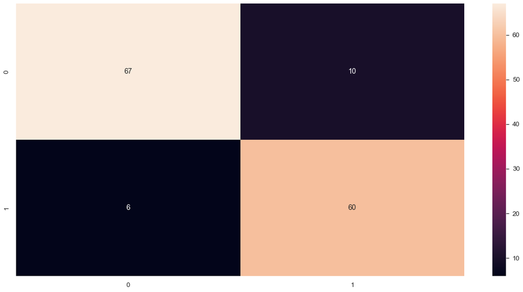

```python
# Display the confusion matrix using a heatmap
y_test_pred = cross_val_predict(best_svm_clf, X_test, y_test, cv=cv)
confusion_mx = confusion_matrix(y_test, y_test_pred)
sns.heatmap(confusion_mx, annot=True, fmt='')
```

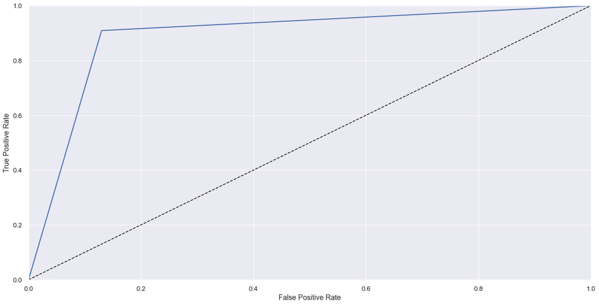

```
AUC: 0.8896
```

```python
# Plot ROC curve and compute AUC score
fpr_svm, tpr_svm, thresholds_svm = roc_curve(y_test, y_test_pred)
plot_roc_curve(fpr_svm, tpr_svm, "SVC")
plt.show()
auc = roc_auc_score(y_test, y_test_pred)
print(f'AUC: {round(auc,4)}')
```

```python
# Display performance metric score for SVM classifier
svm_metrics = print_scores(y_test, y_test_pred)
```

```
Accuracy: 0.8881
Precision: 0.8571
Recall: 0.9091
F1-score: 0.8883
```

### 5. Random Forest Classifier

```python
# define the hyperparameter grid to search over
param_grid = {
    'n_estimators': [650, 700, 750, 800],
    'criterion': ['gini', 'entropy'],
    'max_features': [n_features-9, n_features-8, n_features-5]
}

# initialize the random forest classifier
rf_clf = RandomForestClassifier(random_state=42)

# create a grid search object with cross-validation and scoring metrics
grid_search = GridSearchCV(
    rf_clf, param_grid, cv=5, scoring='accuracy', n_jobs=-1, verbose=1
)

# fit the grid search object on the training data
grid_search.fit(X_train, y_train)

# extract the best estimator and its hyperparameters
best_rf_clf = grid_search.best_estimator_
best_params = grid_search.best_params_

# print the best hyperparameters and the corresponding accuracy score
print("Best hyperparameters: ", best_params)
print("Best accuracy score: ", grid_search.best_score_)
```

```
Fitting 5 folds for each of 24 candidates, totalling 120 fits
Best hyperparameters:  {'criterion': 'gini', 'max_features': 30, 'n_estimators': 650}
Best accuracy score:  0.8298245614035087
```

### Feature importance calculation

```python
importances = best_rf_clf.feature_importances_
indices = np.argsort(importances)[::-1] # sort indices in descending order

print("Feature ranking:")
for f in range(X_train.shape[1]):
    print("%d. %s (%f)" % (f + 1, X_train.columns[indices[f]], importances[indices[f]]))

# Top features: ST_Slope_Up, ChestPainType_ASY, ST_Slope_Flat, Sex, ExerciseAngina
```

```
Feature ranking:
1. ST_Slope_Up (0.327426)
2. ChestPainType_ASY (0.072589)
3. ST_Slope_Flat (0.060089)
4. Sex (0.057265)
5. ExerciseAngina (0.055880)
6. Oldpeak_0 (0.031714)
7. Age_3 (0.031100)
8. MaxHR_3 (0.025020)
9. MaxHR_4 (0.020619)
10. RestingBP_3 (0.019960)
11. FastingBS (0.019094)
12. RestingECG_LVH (0.018726)
13. RestingBP_2 (0.018492)
14. Oldpeak_1 (0.017771)
15. RestingECG_ST (0.017245)
16. Cholesterol_1 (0.016570)
17. RestingBP_1 (0.014859)
18. Cholesterol_3 (0.014446)
19. Age_2 (0.014025)
20. Cholesterol_2 (0.013966)
21. ChestPainType_NAP (0.013568)
22. Age_1 (0.012966)
23. Oldpeak_2 (0.012462)
24. RestingECG_Normal (0.011639)
25. MaxHR_2 (0.011169)
26. ChestPainType_ATA (0.010551)
27. MaxHR_1 (0.009324)
28. Oldpeak_3 (0.008000)
29. Oldpeak_4 (0.007449)
30. ChestPainType_TA (0.007438)
31. RestingBP_0 (0.006071)
32. Age_4 (0.005066)
33. RestingBP_4 (0.004879)
34. ST_Slope_Down (0.004387)
35. Cholesterol_4 (0.003476)
36. Age_0 (0.003181)
37. MaxHR_0 (0.000986)
38. Cholesterol_0 (0.000534)
```

### Model Performance on Train Data

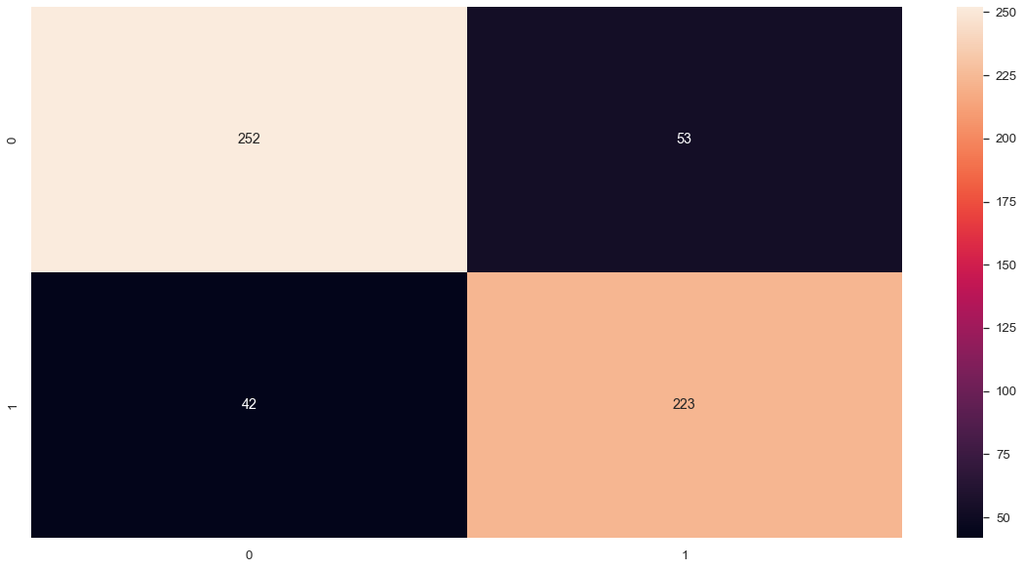

```python
# Display the confusion matrix using a heatmap
y_train_pred = cross_val_predict(best_rf_clf, X_train, y_train, cv=cv)
confusion_mx = confusion_matrix(y_train, y_train_pred)
sns.heatmap(confusion_mx, annot=True, fmt='')
```

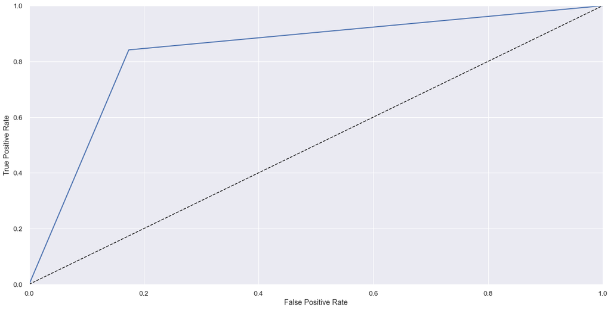

```
AUC score: 0.8339
```

```python
# Plot ROC curve and compute AUC score
fpr_rf, tpr_rf, thresholds_rf = roc_curve(y_train, y_train_pred)
plot_roc_curve(fpr_rf, tpr_rf, "Random Forest")
plt.show()
auc = roc_auc_score(y_train, y_train_pred)
print(f'AUC score: {round(auc, 4)}')
```

### Model Performance on Test Data

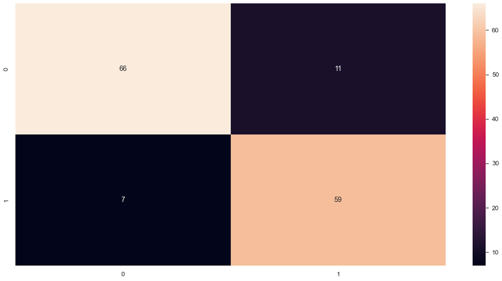

```python
# Display the confusion matrix using a heatmap
y_test_pred = cross_val_predict(best_rf_clf, X_test, y_test, cv=cv)
conf_mx = confusion_matrix(y_test, y_test_pred)
sns.heatmap(conf_mx, annot=True, fmt='')
```

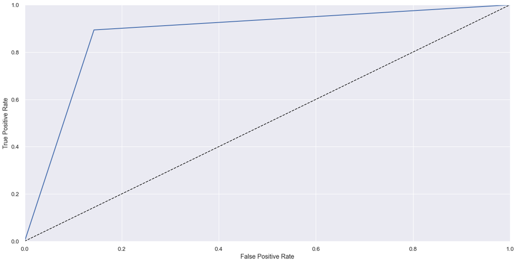

```
AUC score: 0.8755
```

```python
# Plot ROC curve and compute AUC score
fpr_rf, tpr_rf, thresholds_rf = roc_curve(y_test, y_test_pred)
plot_roc_curve(fpr_rf, tpr_rf, "Random Forest")
plt.show()
auc = roc_auc_score(y_test, y_test_pred)
print(f'AUC score: {round(auc, 4)}')
```

```python
# Display performance metric score for Random Forest classifier
rf_metrics = print_scores(y_test, y_test_pred)
```

```
Accuracy: 0.8741
Precision: 0.8429
Recall: 0.8939
F1-score: 0.8743
```

```python
# create a numpy array to store the scores
scores_array = np.array([
    list(lr_metrics.values()),
    list(dt_metrics.values()),
    list(knn_metrics.values()),
    list(svm_metrics.values()),
    list(rf_metrics.values())
])

# create a pandas dataframe from the numpy array
scores_df = pd.DataFrame(scores_array.T, columns=["Logistic Regression","Decision Trees", "K-Nearest Neighbors", "C-Support Vector Machine", "Random Forest"], index=list(knn_metrics.keys()))

# highlight the maximum value in each row with a green color
highlighted_df = scores_df.style.highlight_max(axis=1, color='lightgreen').set_properties(**{'border': '1px solid black', 'font-size': '12px'})

# display the dataframe
display(highlighted_df)
```

|  | Logistic Regression | Decision Trees | K-Nearest Neighbors | C-Support Vector Machine | Random Forest |
| --- | --- | --- | --- | --- | --- |
| accuracy | 0.888112 | 0.895105 | 0.909091 | 0.888112 | 0.874126 |
| precision | 0.867647 | 0.849315 | 0.907692 | 0.857143 | 0.842857 |
| recall | 0.893939 | 0.939394 | 0.893939 | 0.909091 | 0.893939 |
| f1-score | 0.888211 | 0.895249 | 0.909037 | 0.888265 | 0.874299 |